# baseDatosPlasma

Shamuel Manrrique

10/20/2020

# Ejercicio propuesto 1

En el fichero de datos Base Datos Plasma Retinol.tex se tienen las variables cuantitativas CHOLESTEROL, BETADIET, RETDIET, BETAPLASMA y RETPLASMA. En este fichero de texto se comentan esas variables. Además, se dispone de la variable cualitativa (factor) GÉNERO que agrupa los datos en dos niveles: Hombre y Mujer.

## Import libraries

```r
library("RcmdrMisc")
```

```r
library("ggplot2")
library("dplyr")          # load
```

## Cargamos los datos que se encuentran en BaseDatosPlasmaCompleta.RData

```r
load("~/add_practices/practice1/datasets/BaseDatosPlasmaCompleta.RData")
```

## Obtenemos un resumen general de la información del dataset

```r
summary(Dataset)
```

```
##       Edad     Género  Fumador    Quetelet     Vitamina    Calorias
##  41     : 13   1: 42   1:157   Min.   :16.33   1:122    Min.   : 445.2
##  46     : 12   2:273   2:115   1st Qu.:21.80   2: 82    1st Qu.:1338.0
##  49     : 12           3: 43   Median :24.74   3:111    Median :1666.8
##  37     : 11                   Mean   :26.16            Mean   :1796.7
##  44     : 11                   3rd Qu.:28.85            3rd Qu.:2100.4
##  43     : 10                   Max.   :50.40            Max.   :6662.2
##  (Other):246
##      Grasa            Fibra          Alcohol         Cholesterol
##  Min.   : 14.40   Min.   : 3.10   Min.   :  0.000   Min.   :  37.7
##  1st Qu.: 53.95   1st Qu.: 9.15   1st Qu.:  0.000   1st Qu.: 156.8
##  Median : 72.90   Median :12.10   Median :  0.500   Median : 211.7
##  Mean   : 77.03   Mean   :12.79   Mean   :  6.503   Mean   : 255.7
##  3rd Qu.: 95.25   3rd Qu.:15.60   3rd Qu.:  3.850   3rd Qu.: 325.9
##  Max.   :235.90   Max.   :36.80   Max.   :328.000   Max.   :1153.0
##
##     Betadiet       Retdiet         Betaplasma       Retplasma
##  Min.   : 141   Min.   :  27.0   Min.   :   0.0   Min.   : 179.0
##  1st Qu.:1106   1st Qu.: 465.5   1st Qu.:  93.0   1st Qu.: 466.0
##  Median :1802   Median : 706.0   Median : 143.0   Median : 564.0
##  Mean   :2180   Mean   : 823.7   Mean   : 199.4   Mean   : 603.2
##  3rd Qu.:2836   3rd Qu.:1026.5   3rd Qu.: 236.5   3rd Qu.: 721.0
##  Max.   :9642   Max.   :6901.0   Max.   :1415.0   Max.   :1727.0
##                                                   NA's   :6
```

## Estadística descriptiva

Para la variable cuantitativa CHOLESTEROL se considera, en primer lugar, los datos conjuntamente (sin distinguir por género) y, en segundo lugar, agrupando por la variable GÉNERO.

## Datos sin agrupar por GÉNERO

### Analizamos los datos sin agrupación por genero

```r
# Todas las variables cuantitativas
numSummary(Dataset[,c("Cholesterol"), drop=FALSE], statistics=c("mean", "sd", "IQR", "quantiles", "skewness", "kurtosis"), quantiles=c(0,.25,.5,.75,1))
```

```
##      mean       sd    IQR skewness kurtosis   0%   25%   50%    75% 100%   n
##  255.7057 159.1196 169.15 2.176161 7.418406 37.7 156.8 211.7 325.95 1153 315
```

### Gráficas de histograma y box plot de la variable Colesterol:

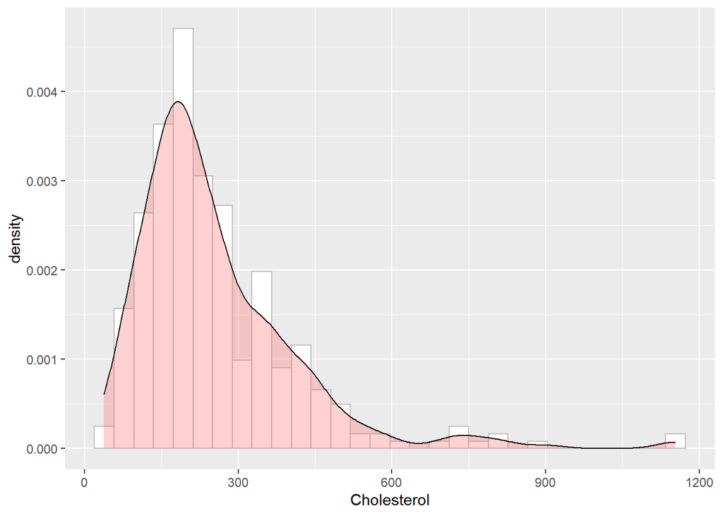

```r
# Histogram with density plot
ggplot(Dataset, aes(x=Cholesterol)) +
 geom_histogram(aes(y=..density..), colour="gray", fill="white", bins = 30) +
 geom_density(alpha=.3, fill="#FF6666")
```

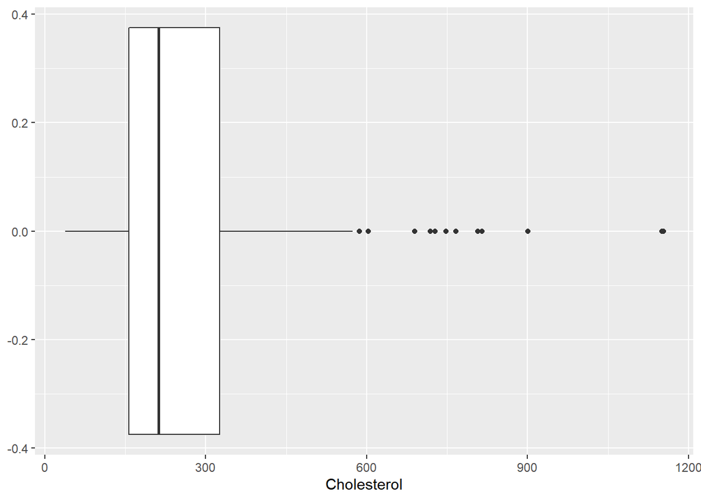

```r
# Basic box plot
ggplot(Dataset, aes(x=Cholesterol)) +
  geom_boxplot()
```

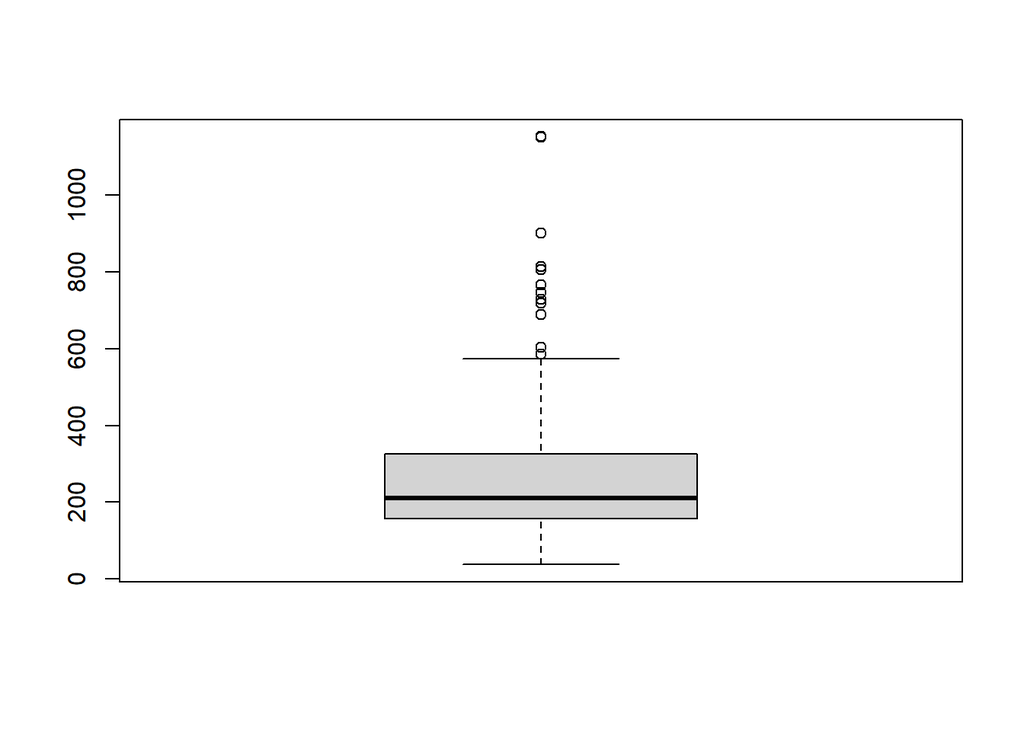

```r
# boxplot
boxplot(Dataset$Cholesterol)
```

Con la Gráfica se puede confirmar el comportamiento *asimétrico positivo esperado.* También al ver los diagramas de cajas no parece tener seguir una distribución normal por la desproporción de sus cuartiles. Por lo que antes de buscar intervalos de confianza y demás datos primero se validará la normalidad.

### Comprobación de normalidad de los datos con distintas pruebas estadísticas

Contraste de Hipótesis:

1. H0: La distribución de la variable aleatoria sigue una distribución normal
2. H1: La distribución de la variable aleatoria no sigue una distribución normal

### Aplicamos algunos test de normalidad como: Shapiro,Anderson-Darling,Cramer

```r
normalityTest(~Cholesterol, test="shapiro.test", data=Dataset) # Shapiro
```

```
##
##  Shapiro-Wilk normality test
##
## data:  Cholesterol
## W = 0.82583, p-value < 2.2e-16
```

```r
normalityTest(~Cholesterol, test="ad.test", data=Dataset)   # Anderson-Darling
```

```
##
##  Anderson-Darling normality test
##
## data:  Cholesterol
## A = 11.667, p-value < 2.2e-16
```

```r
normalityTest(~Cholesterol, test="lillie.test", data=Dataset)
```

```
##
##  Lilliefors (Kolmogorov-Smirnov) normality test
##
## data:  Cholesterol
## D = 0.14001, p-value < 2.2e-16
```

```r
normalityTest(~Cholesterol, test="cvm.test", data=Dataset)  # Cramer
```

```
##
##  Cramer-von Mises normality test
##
## data:  Cholesterol
## W = 1.9866, p-value = 7.37e-10
```

```r
normalityTest(~Cholesterol, test="pearson.test", data=Dataset)
```

```
##
##  Pearson chi-square normality test
##
## data:  Cholesterol
## P = 101.06, p-value = 5.649e-14
```

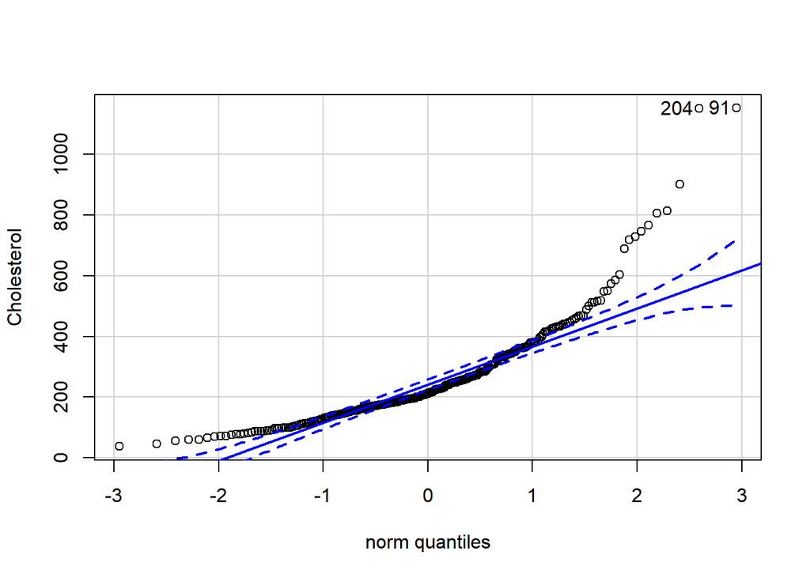

```
## [1]  91 204
```

```r
# QQPlot
with(Dataset, qqPlot(Cholesterol, dist="norm", id=list(method="y", n=2, labels=rownames(Cholesterol))))
```

## los valores arrojados por las pruebas indican que p-value < 2.2e-16 y en el mejor de los casos p-value = 7.37e-10(Cramer) por lo que rechazamos la hipótesis nula y podemos asumir que la función de distribución de la variable aleatoria Colesterol es distinta a la normal. De igual forma se puede corroborar con la gráfica qq-plot se nota que los valores sobresalen en gran parte de los límites, lo que es un indicio de que no hay normalidad.

## Agrupar por el GÉNERO

### Datos agrupando por la variable GÉNERO

Análisis conjunto de las variables cuantitativa CHOLESTEROl agrupada por género

```r
# Resumen estadístico de la variable colesterol por genero
numSummary(Dataset[,c("Cholesterol"), drop=FALSE], groups = Dataset$Género, statistics=c("mean", "sd", "IQR", "quantiles", "skewness", "kurtosis"), quantiles=c(0,.25,.5,.75,1))
```

```
##       mean       sd   IQR  skewness  kurtosis   0% 25%   50%   75%   100%
## 1 328.1238 145.4333 190.2 0.6459659 0.4393445 77.5 227 314.6 417.2  747.5
## 2 244.5645 158.4489 135.7 2.4970890 9.3007085 37.7 151 200.2 286.7 1153.0
##   Cholesterol:n
## 1            42
## 2           273
```

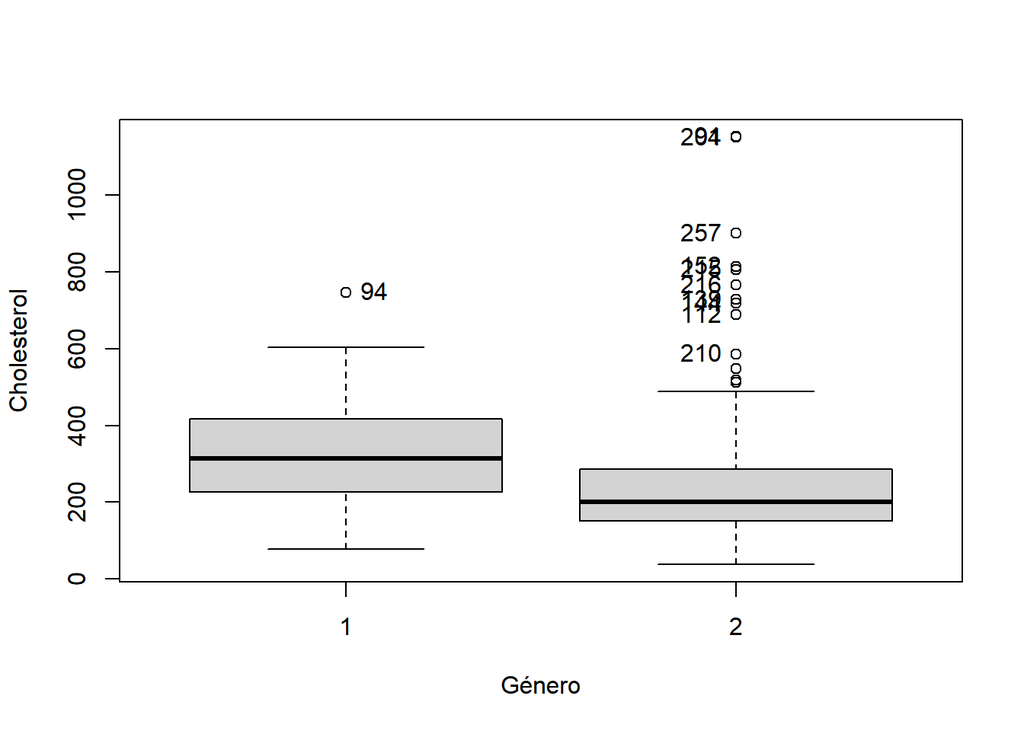

```
##  [1] "94"  "91"  "204" "257" "152" "215" "216" "139" "144" "112" "210"
```

```r
# Grafica de diagrama de caja de Cholesterol~Género
Boxplot(Cholesterol~Género, data=Dataset, id=list(method="y"))
```

Al generar un resumen con los datos agrupados por genero se aprecia que el género 1 cuenta con un total Las 42 muestras de este sexo equivalen a un aproximado del 13.333% de la muestra total, estos datos tienen una media de 328.1238 con valor mínimo 77.5 y máximo 747.5. También se puede notar que el valor de skewness está en un rango aceptable entre cero y uno. Por otro lado, el género 2 tiene un total de 273 que equivale a un 86.666% de la muestra total con una media de 244.5645 con valor mínimo 37.7 y máximo 1153.0. El valor de skewness es bastante elevado(mayor a dos) indica que la distribución es asimétrica positiva.

### Validamos que los datos siguen una distribución Normal

```r
# Prueba de normalidad por Región
normalityTest(Cholesterol~Género, test="shapiro.test", data=Dataset) # Shapiro
```

```
##
##  --------
##  Género = 1
##
##  Shapiro-Wilk normality test
##
## data:  Cholesterol
## W = 0.96649, p-value = 0.2506
##
##  --------
##  Género = 2
##
##  Shapiro-Wilk normality test
##
## data:  Cholesterol
## W = 0.78788, p-value < 2.2e-16
##
##  --------
##
##  p-values adjusted by the Holm method:
##   unadjusted adjusted
## 1 0.25062    0.25062
## 2 < 2e-16    < 2e-16
```

```r
normalityTest(Cholesterol~Género, test="ad.test", data=Dataset)   # Anderson-Darling
```

```
##
##  --------
##  Género = 1
##
##  Anderson-Darling normality test
##
## data:  Cholesterol
## A = 0.44132, p-value = 0.2764
##
##  --------
##  Género = 2
##
##  Anderson-Darling normality test
##
## data:  Cholesterol
## A = 12.58, p-value < 2.2e-16
##
##  --------
##
##  p-values adjusted by the Holm method:
##   unadjusted adjusted
## 1 0.27638    0.27638
## 2 < 2e-16    < 2e-16
```

```r
normalityTest(Cholesterol~Género, test="lillie.test", data=Dataset)
```

```
##
##  --------
##  Género = 1
##
##  Lilliefors (Kolmogorov-Smirnov) normality test
##
## data:  Cholesterol
## D = 0.11392, p-value = 0.1858
##
##  --------
##  Género = 2
##
##  Lilliefors (Kolmogorov-Smirnov) normality test
##
## data:  Cholesterol
## D = 0.14748, p-value = 9.158e-16
##
##  --------
##
##  p-values adjusted by the Holm method:
##   unadjusted adjusted
## 1 0.18576    0.18576
## 2 9.1582e-16 1.8316e-15
```

```r
normalityTest(Cholesterol~Género, test="cvm.test", data=Dataset)  # Cramer
```

[output not shown]

```
##
##  Género = 2
##
##  Cramer-von Mises normality test
##
## data:  Cholesterol
## W = 2.1513, p-value = 7.37e-10
##
##  --------
##
##  p-values adjusted by the Holm method:
##   unadjusted adjusted
## 1 0.24408    0.24408
## 2 7.37e-10   1.474e-09
```

Al realizar las pruebas de normalidad agrupando los datos por Género se obtuvo que el género uno sigue una distribución normal con un p-calor mayor a 0.05. Sin embargo, el género dos no sigue una distribución normal. Por lo que se tendrán que usar otros métodos que no requieran la normalidad de los datos para realizar comparaciones de media y varianza de estos dos conjuntos.

## 2. Determinar si influye el factor GÉNERO en la variable cuantitativa: CHOLESTEROL.

Para determinar si el factor genero influye en la variable CHOLESTEROL validaremos que ambos grupos tienen varianza y media igual, teniendo en cuenta que se deben usar validaciones como Levene (comprobar igualda de varinaza) y Wilcox (comprobar igualdad de media) dado que una de cuando una de las muestras no sigue una distribución normal.

### Validamos si las dos varianzas son iguales o no

```r
# Test Levene para dos varianzas con distribuciones distintas a la normal
leveneTest(Cholesterol~Género, data=Dataset)
```

```
## Levene's Test for Homogeneity of Variance (center = median)
##        Df F value Pr(>F)
## group   1  0.5507 0.4586
##       313
```

```r
leveneTest(Cholesterol~Género, data=Dataset, center=mean)
```

```
## Levene's Test for Homogeneity of Variance (center = mean)
##        Df F value Pr(>F)
## group   1  0.2281 0.6333
##       313
```

```r
# Test Fligner-Killeen para dos varianzas con distribuciones distintas a la normal
fligner.test(Cholesterol~Género, data=Dataset)
```

```
##
##  Fligner-Killeen test of homogeneity of variances
##
## data:  Cholesterol by Género
## Fligner-Killeen:med chi-squared = 3.7732, df = 1, p-value = 0.05208
```

El valor obtenido por el p-value es mayor a 0.05 lo que significa que aceptamos la hipótesis nula y asumimos que no hay una diferencia significativa entre las varianzas del colesterol agrupada por género. Sin embargo el resultado del p-value obtenido con Fligner-Killeen apenas es mayor a 0.05(que se hace en ese caso?)

### Validamos si las dos medias son iguales o no

```r
wilcox.test(Cholesterol~Género, data = Dataset)
```

```
##
##  Wilcoxon rank sum test with continuity correction
##
## data:  Cholesterol by Género
## W = 8037, p-value = 2.764e-05
## alternative hypothesis: true location shift is not equal to 0
```

```r
#wilcox.test(Cholesterol~Género, data = Dataset, paired = TRUE)

#wilcox.test(Dataset~Homicidios, Dataset~Región, alternative = "g")
```

El valor del p-value es menor a 0.05 por lo que rechazo la hipótesis nula y determino que el factor genero influye en el colesterol